# Estimating the effective reproductive number using `ern`

# Introduction

The package `ern` has two functions with which to estimate the daily effective reproduction number, $\mathcal{R}_t$, each for a different data stream:

- `estimate_R_ww()`, which uses the concentration of a pathogen in wastewater over time as the input signal;
- `estimate_R_cl()`, which uses the count of clinical reported cases over time as the input signal.

In both cases, the general method is the same:

1. use the input data to infer daily incidence
2. use the inferred daily incidence to compute $\mathcal{R}_t$

Step 2 is common to both wastewater and clinical methods; where they differ is in step 1. We give details of both steps below, followed by full demos for both wastewater and clinical input data.

## Using inferred daily incidence to compute $\mathcal{R}_t$

In both the clinical and wastewater cases, step 1 will produce an ensemble of realizations for the inferred daily incidence. We use these timeseries of realizations, along with a family of generation interval distributions specified by the user, to compute $\mathcal{R}_t$ in an ensemble of realizations.

To compute a single realization for the $\mathcal{R}_t$ ensemble, we draw one realization out of the ensemble of inferred daily incidence as well as one generation interval distribution out of the user-specified family, and feed both of these components into `EpiEstim::estimate_R()`. Once all realizations of $\mathcal{R}_t$ have been computed, the ensemble is summarized by day with a mean and confidence interval bounds.

Note that the estimation of $R_t$, once the daily incidence has been inferred, is outsourced to the R library `EpiEstim`. Put simply, `ern` is a wrapper around `EpiEstim`.

## Using the input data to infer daily incidence

How we infer daily incidence from the input depends on the input data source.

### Wastewater input data

We convert the pathogen concentration in wastewater over time to a daily disease incidence by performing a deconvolution with a fecal shedding distribution, which describes the distribution of virus shed in feces by an infected individual during their disease course.

### Clinical input data

If the input clinical reports are not daily, `ern` assumes that they are aggregated over the time between report dates and infer the *daily* count of cases using a Markov Chain Monte-Carlo algorithm implemented in the R library `rjags`.

Then, we convert the *daily* count of clinical reports over time to the actual *daily incidence of infections* in the following way:

1. scale daily clinical reports up by the user-specified reporting fraction (assumed to be constant over time)
2. take scaled clinical reports and perform a deconvolution with a reporting delay distribution to get daily scaled onsets
3. take daily scaled onsets and perform a deconvolution with an incubation period distribution to get the daily incidence of infections

# Estimating $\mathcal{R}_t$ with wastewater data

The function `estimate_R_ww()` estimates $R_t$ from pathogen concentration measured in wastewater. It takes several inputs and parameters, described in the next two sections.

## Specifying inputs

`estimate_R_ww()` requires the following inputs from the user:

- `ww.conc`: pathogen concentration in wastewater over time, as a data frame with columns `date` (measurement date) and `value` (concentration value)
- Distribution families for several quantities:
  - `dist.fec`: fecal shedding rate
  - `dist.gi`: generation interval

Here, we estimate $\mathcal{R}_t$ from a subset of wastewater data from the Iona Island wastewater treatment plant in Vancouver.

```r
# Loading sample SARS-CoV-2 wastewater data
ww.conc = ern::ww.data

head(ww.conc)
```

```
#> # A tibble: 6 × 2
#>   date       value
#>   <date>     <dbl>
#> 1 2023-07-23  11.4
#> 2 2023-07-27  38.3
#> 3 2023-07-30  59.4
#> 4 2023-08-03  36.1
#> 5 2023-08-06  24.9
#> 6 2023-08-10  12.0
```

```r
# Define SARS-CoV-2 fecal shedding and generation interval distributions
dist.fec = ern::def_dist(
  dist = "gamma",
  mean = 12.90215,
  mean_sd = 1.136829,
  shape = 1.759937,
  shape_sd = 0.2665988,
  max = 33
)

dist.gi  = ern::def_dist(
  dist     = "gamma",
  mean     = 6.84,
  mean_sd  = 0.7486,
  shape    = 2.39,
  shape_sd = 0.3573,
  max      = 15
)
```

We can visualize the assumed distributions with `plot_dist()`:

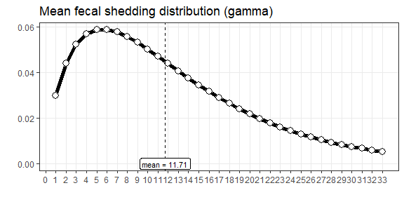

```r
plot_dist(dist.fec) + labs(title = paste0("Mean fecal shedding distribution (", dist.fec$dist, ")"))
```

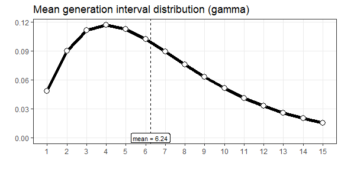

```r
plot_dist(dist.gi) + labs(title = paste0("Mean generation interval distribution (", dist.gi$dist, ")"))
```

`plot_dist()` returns a `ggplot` object, and so it can be further annotated with the usual `ggplot2` tools (like `labs()` as above).

Note that the above `dist.x` lists define *families* of distributions (there is uncertainty specified in the mean distribution parameters), while `plot_dist()` only plots the mean distribution in this family.

## Specifying parameters

`estimate_R_ww()` also takes a number of parameter sets that give the user control over various components of the $\mathcal{R}_t$ estimation:

- `scaling.factor`: a factor used to scale pathogen concentration in wastewater to prevalence (number of infectious cases in the population at a given point in time)
- `prm.smooth`: smoothing settings for the input wastewater data. Pathogen concentration measurements are inherently noisy, hence smoothing the input concentration data usually leads to smoother $R_t$ estimates.
- `prm.R`: settings for the $\mathcal{R}_t$ calculation

All of these parameters have defaults, but they can also be adjusted by the user. These settings are further described in the example below, but you may also want to consult the documentation of `estimate_R_ww()` for more details.

```r
# Initializing scaling factor
scaling.factor = 1

# Initializing smoothing parameters
prm.smooth = list(
  align  = 'center', # smoothing alignment
  method = 'loess',  # smoothing method
  span   = 0.30,     # smoothing span (used for loess smoothing only)
  floor  = 5         # minimum smoothed concentration value (optional, loess smoothing only)
)

# Initialzing Rt settings
prm.R = list(
  iter   = 20,   # number of iterations in Rt ensemble
  CI     = 0.95, # confidence interval
  window = 10,   # Time window for Rt calculations
  config.EpiEstim = NULL # optional EpiEstim configuration for Rt calculations
)
```

## Estimating $\mathcal{R}_t$

Once the above inputs and parameters are defined, we estimate $\mathcal{R}_t$ as follows:

```r
r.estim = ern::estimate_R_ww(
  ww.conc        = ww.conc,
  dist.fec       = dist.fec,
  dist.gi        = dist.gi,
  scaling.factor = scaling.factor,
  prm.smooth     = prm.smooth,
  prm.R = prm.R,
  silent = TRUE # suppress output messages
)
```

`estimate_R_ww()` returns a list with four elements:

- `ww.conc`: the original input of pathogen concentration in wastewater over time
- `ww.smooth`: the smoothed wastewater concentration over time; includes columns:
  - `t`: internal time index
  - `obs`: smoothed value of the observation
  - `date`
- `inc`: the daily incidence inferred over time; includes columns:
  - `date`
  - `mean`: mean of the inferred daily incidence
  - `lwr`, `upr`: lower and upper bounds of a 95% confidence interval of the inferred daily incidence
- `R`: the estimated daily reproduction number over time; includes columns:
  - `date`
  - `mean`: mean $\mathcal{R}_t$ value
  - `lwr`, `upr`: lower and upper bounds of a confidence interval for each $\mathcal{R}_t$ estimate

## Visualizing $\mathcal{R}_t$ estimates

The output of `estimate_R_ww()` can be visualized readily using `plot_diagnostic_ww()`, which generates a figure with the following panels:

1. original wastewater concentration against the smoothed signal over time
2. inferred daily incidence
3. the time-varying effective reproduction number, $\mathcal{R}_t$

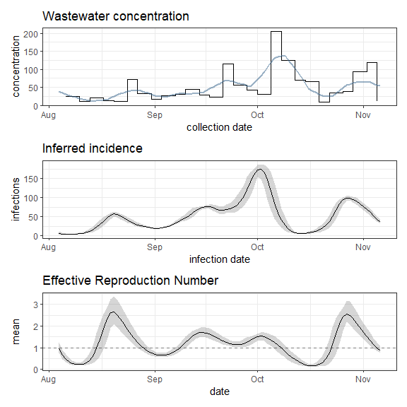

```r
g = ern::plot_diagnostic_ww(r.estim)
plot(g)
```

# Estimating $\mathcal{R}_t$ with clinical data

`estimate_R_cl()` takes several inputs and parameters, described in the next two sections.

## Specifying inputs

`estimate_R_cl()` requires the following inputs from the user:

- `cl.data`: clinical disease reports over time, as a data frame with columns `date` (report date) and `value` (count of reports)
- Distribution families for several quantities:
  - `dist.repdelay`: reporting delay
  - `dist.repfrac`: reporting fraction
  - `dist.incub`: incubation period
  - `dist.gi`: generation interval

Here, we estimate $\mathcal{R}_t$ for a sample of weekly clinical COVID-19 reports in the province of Quebec:

```r
dat <- (ern::cl.data
    |> dplyr::filter(
      pt == "qc",
      dplyr::between(date, as.Date("2021-07-01"), as.Date("2021-09-01"))
))
```

```r
# define reporting delay
dist.repdelay = ern::def_dist(
  dist = 'gamma',
  mean = 5,
  mean_sd = 1,
  sd = 1,
  sd_sd = 0.1,
  max = 10
)

# define reporting fraction
dist.repfrac = ern::def_dist(
  dist = "unif",
  min = 0.1,
  max = 0.3
)

# define incubation period
dist.incub = ern::def_dist(
  dist     = "gamma",
  mean     = 3.49,
  mean_sd  = 0.1477,
  shape    = 8.5,
  shape_sd = 1.8945,
  max      = 8
)

# define generation interval
dist.gi = ern::def_dist(
  dist     = "gamma",
  mean     = 6.84,
  mean_sd  = 0.7486,
  shape    = 2.39,
  shape_sd = 0.3573,
  max      = 15
)
```

We can visualize the assumed distributions with `plot_dist()`:

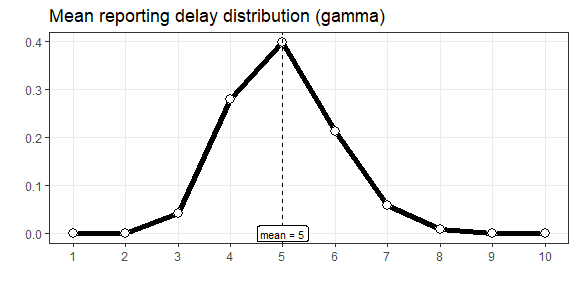

```r
plot_dist(dist.repdelay) + labs(title = paste0("Mean reporting delay distribution (", dist.repdelay$dist, ")"))
```

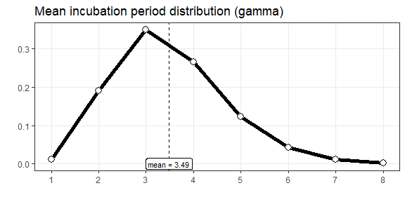

```r
plot_dist(dist.incub) + labs(title = paste0("Mean incubation period distribution (", dist.incub$dist, ")"))
```

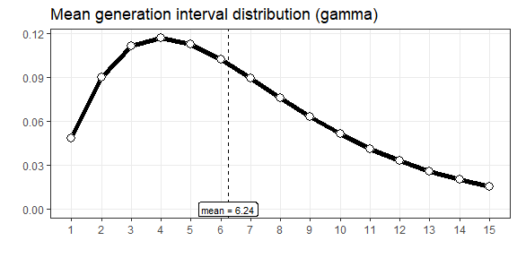

```r
plot_dist(dist.gi) + labs(title = paste0("Mean generation interval distribution (", dist.gi$dist, ")"))
```

`plot_dist()` returns a `ggplot` object, and so it can be further annotated with the usual `ggplot2` tools (like `labs()` as above).

Note that the above `dist.x` lists define *families* of distributions (there is uncertainty specified in the mean distribution parameters), while `plot_dist()` only plots the mean distribution in this family.

## Specifying parameters

`estimate_R_cl()` also takes a number of parameter sets that give the user control over various components of the $\mathcal{R}_t$ estimation:

- `prm.daily`: options for aggregate to daily report inference (only required if input reports are not already daily)
- `prm.daily.check`: options for checking aggregates of inferred daily reports against input values and truncating the start of the timeseries until aggregates are sufficiently close to the input values (only required if input reports are not already daily)
- `prm.smooth`: smoothing settings for the daily reports
- `prm.R`: settings for the $\mathcal{R}_t$ calculation

All of these parameters have defaults, but they can also be adjusted by the user. These settings are further described in the example below, but you may also want to consult the documentation of `estimate_R_cl()` for more details.

```r
# settings for daily report inference
prm.daily = list(
  method = "renewal",
  popsize = 1e7, # population size
   # Here, low value for `burn` and `iter`
   # to have a fast compilation of the vignette.
   # For real-world applications, both `burn` and `iter`
   # should be significantly increased (e.g., 10,000).
   # Also, the number of chains should be at least 3
   # (instead of 1 here) for real-world applications.
  burn = 100,
  iter = 200,
  chains = 1,
  prior_R0_shape = 2,
  prior_R0_rate = 0.6,
  prior_alpha_shape = 1,
  prior_alpha_rate = 1
)

# settings for checks of daily inferred reports
prm.daily.check = list(
  agg.reldiff.tol = 200
)

# smoothing settings for daily inferred reports
prm.smooth = list(
  method = "rollmean",
  window = 3,
  align = 'center'
)

# Rt settings
prm.R = list(
  iter = 10, # number of iterations in Rt ensemble
  CI = 0.95, # 95% confidence interval
  window = 7, # time window for each Rt estimate
  config.EpiEstim = NULL
)
```

## Estimating $\mathcal{R}_t$

Once the above inputs and parameters are defined, we estimate $\mathcal{R}_t$ as follows:

```r
r.estim = estimate_R_cl(
  cl.data      = dat,
  dist.repdelay = dist.repdelay,
  dist.repfrac  = dist.repfrac,
  dist.incub    = dist.incub,
  dist.gi       = dist.gi,
  prm.daily     = prm.daily,
  prm.daily.check = prm.daily.check,
  prm.smooth    = prm.smooth,
  prm.R         = prm.R,
  silent        = TRUE # suppress output messages
)
```

`estimate_R_cl()` returns a list with four elements:

- `cl.data`: the original input of clinical disease reports over time
- `cl.daily`: reports as input for Rt calculation (inferred daily counts if original inputs were aggregates, smoothed if specified); includes columns:
  - `id`: identifier for each realization of the daily report inference
  - `date`: daily date
  - `value`: inferred daily report count
  - `t`: internal time index
- `inferred.agg`: inferred daily reports re-aggregated on the reporting schedule as input in `cl.data`; includes columns:
  - `date`: report date
  - `obs`: original (aggregated) observations
  - `mean.agg`: mean of the aggregated inferred daily reports
  - `lwr.agg`, `upr.agg`: lower and upper bounds of a 95% confidence interval of the aggregated inferred daily reports
- `R`: the estimated daily reproduction number over time; includes columns:
  - `date`
  - `mean`: mean $\mathcal{R}_t$ value
  - `lwr`, `upr`: lower and upper bounds of a confidence interval for each $\mathcal{R}_t$ estimate
  - `use`: logical flag used internally for the plotting method demonstrated below

## Visualizing $\mathcal{R}_t$ estimates

The output of `estimate_R_cl()` can be visualized readily using `plot_diagnostic_cl()`, which generates a figure with the following panels:

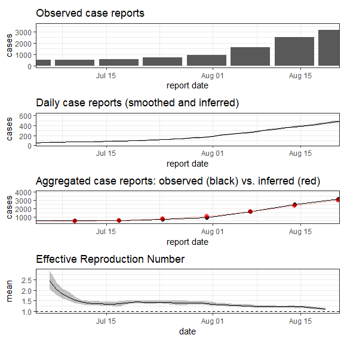

```r
g = plot_diagnostic_cl(r.estim)
plot(g)
```